# STATS 503 HW3

## Shuo Qin

### Question 1

Since we know from 4.2 that $$p(X) = \frac{e^{\beta_0 + \beta_1X}}{1+e^{\beta_0 + \beta_1X}}$$, then we can calculate $$1-p(X) = 1-\frac{e^{\beta_0 + \beta_1X}}{1+e^{\beta_0 + \beta_1X}} = \frac{1}{1+e^{\beta_0 + \beta_1X}}$$, then using this to calculate the ratio of $$\frac{p(X)}{1-p(X)} = e^{\beta_0+ \beta_1X}$$ which is 4.3.

### Question 2

(a) Since X has a uniform distribution and we wish to predict a test observation’s response using only observations that are within 10 % of the range of X closest to that test observation, I believe that on average, 10% of the available observations will be used to make predictions.

(b) This is quite similar to the previous question but since it is a 2-dimensional case, we need to multiply 10% by 10% which is 0.01 = 1%.

(c) Since now p = 100, we can use (0.1)^100 which is a very small number that can be seen as 0.

(d) From the result a-c, we can clearly tell that as the dimensionality p increase, the fraction of the available observations will we use to make the prediction is getting smaller and smaller and eventually it goes to 0. This shows that there are very few training observations “near” any given test observation when p is large while using the KNN method.

(e) To calculate the length of each cube, we can plug in numbers for the formula length = 0.1^(1/p). For p = 1, the length of the cube is 0.1. For p=2, the length of the cube is 0.1^(1/2) which is about 0.316. For p = 100, the length is 0.1^(1/100) which is around 0.977.

### Question 3

(a)Since $$\frac{p(X)}{1-p(X)} = 0.37$$, we can do the algebra and get $$p(X) = 0.27$$

(b)Since $$p(X) = 0.16$$, we can use this calculate using the formula $$\frac{p(X)}{1-p(X)} $$ and get the result 0.19.

### Question 4

(a) By the formula of log odd in the lecture, the answer to this question is $$ \hat{{\beta_0}} + \hat{\beta_1}X$$.

(b) Following the formula in the question, we get $$\hat{\alpha}orange0+ \hat{\alpha}orange1x - \hat{\alpha}apple0 - \hat{\alpha}apple1x $$

(c) By the given data, we have: $$ \hat{P}(Y=orange|X=x) = \frac{exp(2-x)}{1+exp(2-x)}$$ and then, $$ \hat{P}(Y=apple|X=x) = \frac{1}{1+exp(2-x)}.$$ So then by comparing to the logistic regression formula to the friend's formula, we get that when: $$ \hat{P}(Y=orange|X=x), \hat{\alpha}orange0 = 2, \hat{\alpha}orange1 = -1 $$ $$ \hat{P}(Y=apple|X=x), \hat{\alpha}apple0 = 0, \hat{\alpha}apple1 = 0 $$

### Question 5

(a) So plugging the number, we have $$\frac{1}{1+exp(-(-4)-0.05*5-3.5)} = 0.4378.$$ The student has a 43.8% chance of getting an A in the class.

(b) $$ odds = \frac{0.4378}{1-0.4378} = 0.779 $$

The odd is 0.779.

(c) $$ 0.5 = \frac{1}{1+exp(4-0.05x-3.5)}$$ $$ x = 10 $$ This student need to student 10 hours a week in order to have a 50% chance of getting an A in this class.

### Question 6

```python
import numpy as np
import pandas as pd
import matplotlib.pyplot as plt
import seaborn as sns
import os
import matplotlib.pyplot as plt
%matplotlib inline
from sklearn import metrics
import sklearn.model_selection
import sklearn.linear_model
import sklearn.metrics
from sklearn.preprocessing import LabelEncoder
```

```python
college_train = pd.read_csv('college_train.csv')
college_test = pd.read_csv('college_test.csv')
```

```python
college_train = college_train.drop(['Name'], axis = 1)
```

```python
college_train.head()
```

|  | Private | Apps | Accept | Enroll | Top10perc | Top25perc | F.Undergrad | P.Undergrad | Outstate | Room.Board | Books | Personal | PhD | Terminal | S.F.Ratio | perc.alumni | Expend | Grad.Rate |
| --- | --- | --- | --- | --- | --- | --- | --- | --- | --- | --- | --- | --- | --- | --- | --- | --- | --- | --- |
| 0 | No | 2729 | 2535 | 1257 | 8 | 29 | 4787 | 472 | 3735 | 3136 | 250 | 1630 | 62 | 65 | 21.7 | 23 | 5284 | 54 |
| 1 | Yes | 2190 | 1700 | 458 | 36 | 65 | 1780 | 48 | 16732 | 5650 | 550 | 550 | 93 | 93 | 12.1 | 32 | 12011 | 75 |
| 2 | No | 950 | 713 | 351 | 42 | 72 | 1276 | 9 | 14320 | 5304 | 490 | 1410 | 77 | 77 | 14.9 | 17 | 8837 | 87 |
| 3 | Yes | 1096 | 951 | 464 | 27 | 62 | 1776 | 239 | 8150 | 3150 | 400 | 500 | 61 | 62 | 13.6 | 16 | 6716 | 67 |
| 4 | No | 12809 | 10308 | 3761 | 24 | 49 | 22593 | 7585 | 7434 | 4850 | 700 | 2100 | 88 | 93 | 18.9 | 5 | 4602 | 48 |

```python
college_test = college_test.drop(['Name'], axis = 1)
```

```python
college_test.head()
```

|  | Private | Apps | Accept | Enroll | Top10perc | Top25perc | F.Undergrad | P.Undergrad | Outstate | Room.Board | Books | Personal | PhD | Terminal | S.F.Ratio | perc.alumni | Expend | Grad.Rate |
| --- | --- | --- | --- | --- | --- | --- | --- | --- | --- | --- | --- | --- | --- | --- | --- | --- | --- | --- |
| 0 | No | 910 | 910 | 342 | 14 | 53 | 1434 | 417 | 7032 | 2780 | 550 | 1960 | 75 | 81 | 15.2 | 15 | 6490 | 36 |
| 1 | Yes | 511 | 411 | 186 | 23 | 51 | 1692 | 562 | 12224 | 4440 | 450 | 1000 | 63 | 87 | 11.5 | 32 | 7315 | 77 |
| 2 | Yes | 812 | 689 | 195 | 7 | 24 | 646 | 84 | 8242 | 4230 | 600 | 1295 | 77 | 77 | 12.7 | 11 | 10090 | 52 |
| 3 | Yes | 4302 | 992 | 418 | 83 | 96 | 1593 | 5 | 19760 | 5300 | 660 | 1598 | 93 | 98 | 8.4 | 63 | 21424 | 100 |
| 4 | Yes | 576 | 558 | 137 | 11 | 39 | 662 | 131 | 10430 | 3620 | 400 | 1500 | 85 | 98 | 16.5 | 18 | 8767 | 45 |

```python
le = LabelEncoder()
college_train['Private'] = le.fit_transform(college_train['Private'])
college_train.head()
```

|  | Private | Apps | Accept | Enroll | Top10perc | Top25perc | F.Undergrad | P.Undergrad | Outstate | Room.Board | Books | Personal | PhD | Terminal | S.F.Ratio | perc.alumni | Expend | Grad.Rate |
| --- | --- | --- | --- | --- | --- | --- | --- | --- | --- | --- | --- | --- | --- | --- | --- | --- | --- | --- |
| 0 | 0 | 2729 | 2535 | 1257 | 8 | 29 | 4787 | 472 | 3735 | 3136 | 250 | 1630 | 62 | 65 | 21.7 | 23 | 5284 | 54 |
| 1 | 1 | 2190 | 1700 | 458 | 36 | 65 | 1780 | 48 | 16732 | 5650 | 550 | 550 | 93 | 93 | 12.1 | 32 | 12011 | 75 |
| 2 | 0 | 950 | 713 | 351 | 42 | 72 | 1276 | 9 | 14320 | 5304 | 490 | 1410 | 77 | 77 | 14.9 | 17 | 8837 | 87 |
| 3 | 1 | 1096 | 951 | 464 | 27 | 62 | 1776 | 239 | 8150 | 3150 | 400 | 500 | 61 | 62 | 13.6 | 16 | 6716 | 67 |
| 4 | 0 | 12809 | 10308 | 3761 | 24 | 49 | 22593 | 7585 | 7434 | 4850 | 700 | 2100 | 88 | 93 | 18.9 | 5 | 4602 | 48 |

```python
college_test['Private'] = le.fit_transform(college_test['Private'])
college_test.head()
```

|  | Private | Apps | Accept | Enroll | Top10perc | Top25perc | F.Undergrad | P.Undergrad | Outstate | Room.Board | Books | Personal | PhD | Terminal | S.F.Ratio | perc.alumni | Expend | Grad.Rate |
| --- | --- | --- | --- | --- | --- | --- | --- | --- | --- | --- | --- | --- | --- | --- | --- | --- | --- | --- |
| 0 | 0 | 910 | 910 | 342 | 14 | 53 | 1434 | 417 | 7032 | 2780 | 550 | 1960 | 75 | 81 | 15.2 | 15 | 6490 | 36 |
| 1 | 1 | 511 | 411 | 186 | 23 | 51 | 1692 | 562 | 12224 | 4440 | 450 | 1000 | 63 | 87 | 11.5 | 32 | 7315 | 77 |
| 2 | 1 | 812 | 689 | 195 | 7 | 24 | 646 | 84 | 8242 | 4230 | 600 | 1295 | 77 | 77 | 12.7 | 11 | 10090 | 52 |
| 3 | 1 | 4302 | 992 | 418 | 83 | 96 | 1593 | 5 | 19760 | 5300 | 660 | 1598 | 93 | 98 | 8.4 | 63 | 21424 | 100 |
| 4 | 1 | 576 | 558 | 137 | 11 | 39 | 662 | 131 | 10430 | 3620 | 400 | 1500 | 85 | 98 | 16.5 | 18 | 8767 | 45 |

```python
X_train = college_train.drop('Private', axis=1)
y_train = college_train['Private']

X_test = college_test.drop('Private', axis=1)
y_test = college_test['Private']
```

```python
model_log = sklearn.linear_model.LogisticRegression(max_iter=10000000)
model_log.fit(X_train,y_train)
```

```
LogisticRegression(max_iter=10000000)
```

#### (a)

```python
y_prob = model_log.predict_proba(X_test)

# show logistic regression's estimated probability mass function along with the true value of y_i for each test point
viz_table=pd.DataFrame(data=np.c_[y_prob,y_test],columns=['$\hat p(0|x_i)$','$\hat p(1|x_i)$','$y_i$'])
viz_table
```

|  | $\hat p(0\|x_i)$ | $\hat p(1\|x_i)$ | $y_i$ |
| --- | --- | --- | --- |
| 0 | 0.580907 | 0.419093 | 0.0 |
| 1 | 0.003309 | 0.996691 | 1.0 |
| 2 | 0.149523 | 0.850477 | 1.0 |
| 3 | 0.000002 | 0.999998 | 1.0 |
| 4 | 0.214085 | 0.785915 | 1.0 |
| ... | ... | ... | ... |
| 122 | 0.001496 | 0.998504 | 1.0 |
| 123 | 0.001497 | 0.998503 | 1.0 |
| 124 | 0.000348 | 0.999652 | 1.0 |
| 125 | 0.002302 | 0.997698 | 1.0 |
| 126 | 0.998557 | 0.001443 | 0.0 |

127 rows × 3 columns

```python
## negative loglikelihood
pygx = y_prob[np.r_[0:len(y_test)],y_test]
viz_table['$\hat p(y_i|x_i)$']=pygx
viz_table
```

|  | $\hat p(0\|x_i)$ | $\hat p(1\|x_i)$ | $y_i$ | $\hat p(y_i\|x_i)$ |
| --- | --- | --- | --- | --- |
| 0 | 0.580907 | 0.419093 | 0.0 | 0.580907 |
| 1 | 0.003309 | 0.996691 | 1.0 | 0.996691 |
| 2 | 0.149523 | 0.850477 | 1.0 | 0.850477 |
| 3 | 0.000002 | 0.999998 | 1.0 | 0.999998 |
| 4 | 0.214085 | 0.785915 | 1.0 | 0.785915 |
| ... | ... | ... | ... | ... |
| 122 | 0.001496 | 0.998504 | 1.0 | 0.998504 |
| 123 | 0.001497 | 0.998503 | 1.0 | 0.998503 |
| 124 | 0.000348 | 0.999652 | 1.0 | 0.999652 |
| 125 | 0.002302 | 0.997698 | 1.0 | 0.997698 |
| 126 | 0.998557 | 0.001443 | 0.0 | 0.998557 |

127 rows × 4 columns

```python
-np.mean(np.log(pygx))
```

```
0.13180506922862315
```

```python
sklearn.metrics.log_loss(y_test, y_prob)
```

```
0.13180506922862315
```

So the negative loglikelihood is around 0.1318.

#### (b)

```python
thresh = 0.5
y_pred = np.where(y_prob[:,1] > thresh,1,0)
pd.DataFrame({'phat(1|x_i)':y_prob[:,1],'yhat(3|x_i)':y_pred})
```

|  | phat(1\|x_i) | yhat(3\|x_i) |
| --- | --- | --- |
| 0 | 0.419093 | 0 |
| 1 | 0.996691 | 1 |
| 2 | 0.850477 | 1 |
| 3 | 0.999998 | 1 |
| 4 | 0.785915 | 1 |
| ... | ... | ... |
| 122 | 0.998504 | 1 |
| 123 | 0.998503 | 1 |
| 124 | 0.999652 | 1 |
| 125 | 0.997698 | 1 |
| 126 | 0.001443 | 0 |

127 rows × 2 columns

```python
cnf_matrix = sklearn.metrics.confusion_matrix(y_test, y_pred)
cnf_matrix
```

```
array([[32,  1],
       [ 5, 89]])
```

```python
FP = cnf_matrix[0,1]
FN = cnf_matrix[1,0]
TP = cnf_matrix[1,1]
TN = cnf_matrix[0,0]

FP = FP.astype(float)
FN = FN.astype(float)
TP = TP.astype(float)
TN = TN.astype(float)
```

```python
metrics=pd.Series(dict(
    FPR = FP/(FP+TN),
    TPR = TP/(TP+FN),
    FNR = FN/(TP+FN),
    TNR = TN/(TN+FP)
))
metrics
```

```
FPR    0.030303
TPR    0.946809
FNR    0.053191
TNR    0.969697
dtype: float64
```

#### (c)

```python
thresh = 0.9
y_pred = np.where(y_prob[:,1] > thresh,1,0)
pd.DataFrame({'phat(1|x_i)':y_prob[:,1],'yhat(3|x_i)':y_pred})
```

|  | phat(1\|x_i) | yhat(3\|x_i) |
| --- | --- | --- |
| 0 | 0.419093 | 0 |
| 1 | 0.996691 | 1 |
| 2 | 0.850477 | 0 |
| 3 | 0.999998 | 1 |
| 4 | 0.785915 | 0 |
| ... | ... | ... |
| 122 | 0.998504 | 1 |
| 123 | 0.998503 | 1 |
| 124 | 0.999652 | 1 |
| 125 | 0.997698 | 1 |
| 126 | 0.001443 | 0 |

127 rows × 2 columns

```python
cnf_matrix = sklearn.metrics.confusion_matrix(y_test, y_pred)
cnf_matrix
```

```
array([[32,  1],
       [21, 73]])
```

```python
FP = cnf_matrix[0,1]
FN = cnf_matrix[1,0]
TP = cnf_matrix[1,1]
TN = cnf_matrix[0,0]

FP = FP.astype(float)
FN = FN.astype(float)
TP = TP.astype(float)
TN = TN.astype(float)
```

```python
metrics=pd.Series(dict(
    FPR = FP/(FP+TN),
    TPR = TP/(TP+FN),
    FNR = FN/(TP+FN),
    TNR = TN/(TN+FP)
))
metrics
```

```
FPR    0.030303
TPR    0.776596
FNR    0.223404
TNR    0.969697
dtype: float64
```

#### (d)

```python
thresholds = np.arange(0, 1.01, 0.01)
tprs = []
fprs = []

for thresh in thresholds:
    y_pred = np.where(y_prob[:,1] > thresh,1,0)
    cnf_matrix = sklearn.metrics.confusion_matrix(y_test, y_pred)

    FP = cnf_matrix[0,1]
    FN = cnf_matrix[1,0]
    TP = cnf_matrix[1,1]
    TN = cnf_matrix[0,0]

    FP = FP.astype(float)
    FN = FN.astype(float)
    TP = TP.astype(float)
    TN = TN.astype(float)

    FPR = FP/(FP+TN)
    TPR = TP/(TP+FN)

    fprs.append(FPR)
    tprs.append(TPR)
```

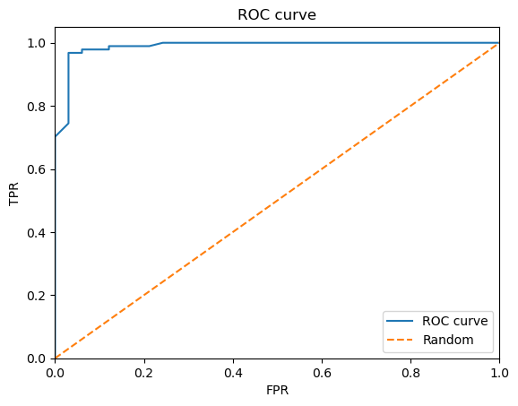

```python
plt.figure()
plt.plot(fprs, tprs, label='ROC curve')
plt.plot([0, 1], [0, 1], linestyle='--', label='Random')
plt.xlim([0.0, 1.0])
plt.ylim([0.0, 1.05])
plt.xlabel('FPR')
plt.ylabel('TPR')
plt.title('ROC curve')
plt.legend(loc="lower right")
plt.show()
```

```python
sklearn.metrics.roc_auc_score(y_test, y_prob[:,1])
```

```
0.9880722114764668
```